# 11. Self-calibrated CS-pMR image reconstruction from undersampled Cartesian data In this tutorial we will reconstruct an MRI image from Cartesian undersampled kspace data.

Let us denote $\Omega$ the undersampling mask, the under-sampled Fourier transform now reads $F_{\Omega}$. We use the toy datasets available in pysap, more specifically a 2D brain slice and under-sampled Cartesian acquisition over 32 channels. We compare zero-order image reconstruction with **self-calibrated** multi-coil Compressed sensing reconstructions (analysis vs synthesis formulation) using the FISTA algorithm for the synthesis formulation and the Condat-Vu algorithm for the analysis formulation. The multicoil data $(y_\ell)_\ell$ is collected across multiple, say $L$, channels. The sensitivity maps $(S_\ell)_\ell$ are automically calibrated from the central portion of k-space (e.g. 5%) for all channels $\ell=1, \ldots, L$. We remind that the synthesis formulation of the non-Cartesian CS-PMRI problem reads (minimization in the sparsifying domain):

$$ \widehat{z} = \text{arg}\,\min_{z\in C^n_\Psi} \frac{1}{2} \sum_{\ell=1}^L\|y_\ell - F_\Omega S_\ell \Psi^*z \|_2^2 + \lambda \|z\|_1 $$

and the image solution is given by $\widehat{x} = \Psi^*\widehat{z}$. For an orthonormal wavelet transform, we have $n_\Psi=n$ while for a frame we may have $n_\Psi > n$. while the analysis formulation consists in minimizing the following cost function (min. in the image domain):

$$ \widehat{x} = \text{arg}\,\min_{x\in C^n} \frac{1}{2} \sum_{\ell=1}^L \|y_\ell - F_\Omega S_\ell x\|_2^2 + \lambda \|\Psi x\|_1 \,. $$

- Author: Chaithya G R & Philippe Ciuciu
- Date: 01/06/2021, update: 02/13/2024
- Target: ATSI MSc students, Paris-Saclay University

```python
# 导入 MRI 重建运算符
# Package import
from mri.operators import FFT, WaveletN
'''
WaveletN : 正交小波变换（如 Symmlet-8 或 Daubechies），用于 合成公式（Synthesis Formulation） 压缩感知重建。
WaveletUD2 : 未降采样双正交小波变换（Undecimated Bi-Orthogonal Wavelet Transform），用于 分析公式（Analysis Formulation） 压缩感知重建。
'''
# 导入 MRI 处理的实用工具
from mri.operators.utils import convert_mask_to_locations
'''
convert_mask_to_locations ：2D binary mask -> a list of sampled k-space coordinates (x, y)
'''
#  导入 MRI 图像重建器
from mri.reconstructors.utils.extract_sensitivity_maps \
    import get_Smaps, extract_k_space_center_and_locations
from mri.reconstructors import SelfCalibrationReconstructor
'''
get_Smaps ：从 k-space 提取 灵敏度图（Sensitivity Maps），用于 多通道 MRI 重建（pMRI）。
extract_k_space_center_and_locations ：获取 K-space 采样中心，用于自校准（Self-Calibration）。
SelfCalibrationReconstructor ：用于 基于自校准（Self-Calibrated）策略 进行 MRI 图像重建。
'''

# 导入 MRI 样本数据
from pysap.data import get_sample_data

# Third party import
from modopt.math.metrics import ssim
from modopt.opt.linear import Identity
from modopt.opt.proximity import SparseThreshold
'''
ssim : 结构相似性指数（SSIM），用于 评估重建图像的质量，与原始 MRI 进行比较。
Identity : 单位变换（Identity Transformation），即 不对数据做任何变换，在优化过程中常用于保持数据结构。
SparseThreshold : 稀疏阈值运算（L1 正则化 / 软阈值收缩），用于 压缩感知重建中的稀疏性约束。
'''

import numpy as np
import matplotlib.pyplot as plt
```

## Loading input data

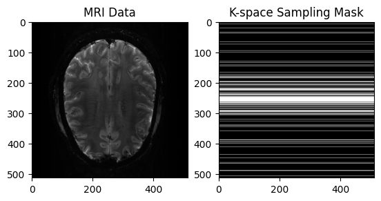

```python
# Loading input data
cartesian_ref_image = get_sample_data('2d-pmri')
image = np.linalg.norm(cartesian_ref_image, axis=0)
# Obtain MRI cartesian mask
mask = get_sample_data("cartesian-mri-mask").data

# View Input
plt.subplot(1, 2, 1)
plt.imshow(np.abs(image), cmap='gray')
plt.title("MRI Data")
plt.subplot(1, 2, 2)
plt.imshow(mask, cmap='gray')
plt.title("K-space Sampling Mask")
plt.show()
```

```python
mask_sampled = np.where(mask==1)
print(512**2/np.size(mask_sampled))
```

```
2.6122448979591835
```

```python
print( f" image data base : \n {cartesian_ref_image.shape}")
```

```
 image data base :
 (32, 512, 512)
```

```python
print( f"image shape : \n {image.shape} \n ")

print( f"sampled lines : \n {(np.where(mask[:,0]==1))}")
```

```
image shape :
 (512, 512)

sampled lines :
 (array([  8,  21,  35,  38,  66,  74,  95, 100, 130, 134, 142, 146, 166,
       173, 177, 180, 182, 183, 185, 195, 197, 198, 203, 206, 207, 210,
       215, 219, 220, 221, 222, 223, 225, 226, 232, 235, 237, 238, 239,
       241, 244, 245, 247, 248, 249, 250, 251, 252, 253, 254, 255, 256,
       257, 258, 259, 260, 261, 262, 264, 265, 266, 267, 270, 271, 272,
       277, 278, 283, 285, 290, 292, 293, 294, 295, 297, 301, 302, 304,
       306, 320, 326, 339, 341, 345, 358, 387, 388, 393, 396, 400, 411,
       436, 447, 462, 465, 488, 489, 506]),)
```

$\leadsto$ The code above is to generate the mask, the key part is

`mask = get_sample_data("cartesian-mri-mask").data`

where we use the package to import the `cartesian-mri-mask` already existing.

```
phase_encoding_locs:
 [ 0.          0.00195312 -0.00195312  0.00390625 -0.00390625  0.00585938
 -0.00585938  0.0078125  -0.0078125   0.00976562 -0.00976562  0.01171875
 -0.01171875  0.01367188 -0.01367188  0.015625   -0.015625    0.01757812
 -0.01757812  0.01953125 -0.01953125  0.02148438 -0.02148438  0.0234375
 -0.0234375   0.02539062 -0.02539062  0.02734375 -0.02734375  0.02929688
 -0.02929688  0.03125    -0.03125     0.03320312 -0.03320312  0.03515625
 -0.03515625  0.03710938 -0.03710938  0.0390625  -0.0390625   0.04101562
 -0.04101562  0.04296875 -0.04296875  0.04492188 -0.04492188  0.046875
 -0.046875    0.04882812 -0.04882812  0.06054688 -0.05078125  0.06640625
 -0.0546875   0.07226562 -0.05859375  0.07617188 -0.06835938  0.078125
 -0.0703125   0.08398438 -0.078125    0.09960938 -0.0859375   0.1015625
 -0.08984375  0.10351562 -0.109375    0.11914062 -0.11328125  0.12695312
 -0.1171875   0.140625   -0.12304688  0.14453125 -0.1484375   0.15039062
 -0.15234375  0.1640625  -0.15625     0.16601562 -0.171875    0.17578125
 -0.17773438  0.18359375 -0.18554688  0.1953125  -0.20117188  0.19921875
 -0.21679688  0.21679688 -0.21875     0.24023438 -0.22851562  0.27148438
 -0.26171875  0.27734375 -0.29296875  0.3046875  -0.29492188  0.32226562
  0.34375     0.3515625   0.36914062  0.40234375  0.41210938  0.49804688]

min(phase_encoding_locs):
 -0.294921875

max(phase_encoding_locs):
 0.498046875
```

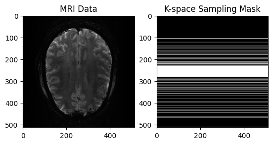

```python
# Alternative design of 1D VDS

# 2. 生成随机相位编码位置
from mrinufft.trajectories.tools import get_random_loc_1d

# 3. 生成相位编码采样位置
'''
image.shape[0]：图像的宽度/高度（假设是 正方形 MRI 图像）
accel=8：加速因子 = 8，即减少 8 倍的 K-Space 采样（加速 MRI 采集）
center_prop=0.1：中心 10% 的 K-Space 总是被采样（通常低频区域更重要）。
pdf='gaussian'：按照高斯分布进行随机采样（中心采样密集，边缘较稀疏）
'''
phase_encoding_locs = get_random_loc_1d(image.shape[0], accel=8, center_prop=0.1, pdf='gaussian')
print(f"phase_encoding_locs: \n {phase_encoding_locs}"  +
      f"\n\nmin(phase_encoding_locs): \n {min(phase_encoding_locs)}" +
      f"\n\nmax(phase_encoding_locs): \n {max(phase_encoding_locs)}")
#print(phase_encoding_locs, min(phase_encoding_locs), max(phase_encoding_locs))

# 4. 调整相位编码位置
'''
+0.5：偏移到中心
* image.shape[0]：映射到像素索引范围（0 ~ image.shape[0]）
.astype(int)：转换为整数索引
'''
phase_encoding_locs = ((phase_encoding_locs +0.5) * image.shape[0]).astype(int)

# 5. 生成 K-Space 采样掩码
mask = np.zeros(image.shape, dtype=bool)                    # 创建一个全零的掩码
mask[phase_encoding_locs] = 1                               # 只在选定的位置设置为 1

# View Input
plt.subplot(1, 2, 1)
plt.imshow(np.abs(image), cmap='gray')
plt.title("MRI Data")
plt.subplot(1, 2, 2)
plt.imshow(mask, cmap='gray')
plt.title("K-space Sampling Mask")
plt.show()
```

## Generate the kspace

From the 2D brain slice and the acquisition mask, we retrospectively undersample the k-space using a cartesian acquisition mask. We then reconstruct the zero order solution as a baseline

```python
# 2. Define the Fourier operator (FFT)

# Get the locations of the kspace samples and the associated observations
fourier_op = FFT(mask=mask, shape=image.shape,
                 n_coils=cartesian_ref_image.shape[0])

# 3. Generate the undersampled k-space data
'''
.op(cartesian_ref_image) applies the forward Fourier transform (FFT) only at the sampled locations corresponding to the mask
kspace_obs is a subsampled k-space representation of the image with size (32, 512, 512) .
'''
kspace_obs = fourier_op.op(cartesian_ref_image)
```

Zero order solution

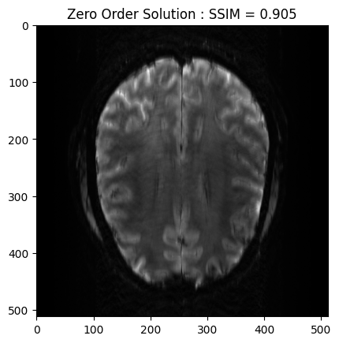

```python
# Zero order solution

# Perform the inverse Fourier transform
zero_soln = np.linalg.norm(fourier_op.adj_op(kspace_obs), axis=0)
base_ssim = ssim(zero_soln, image)
plt.imshow(np.abs(zero_soln), cmap='gray')
plt.title('Zero Order Solution : SSIM = ' + str(np.around(base_ssim, 3)))
plt.show()
```

$\leadsto$ Here we apply the Fourier operator and its ajoint to perform the zero order solution :

- `fourier_op = FFT(samples=kspace_loc, shape=image.shape)` `fourier_op = FFT(mask=mask, shape=image.shape, n_coils=cartesian_ref_image.shape[0])`

  where we define the **Fourier transform** (FFT) operator only for the sampled locations corresponding to the `mask` ,

  then we apply this operator to the `image` : `kspace_obs = fourier_op.op(cartesian_ref_image)` to obtain the undersampled k-space obs data.
- To compute the zero order solution, we just apply the ajoint of the operator `zero_soln = np.linalg.norm(fourier_op.adj_op(kspace_obs), axis=0)`, which serves as a basic reconstruction:

**Q1**

- Observe and comment the improved image quality on the zero-filled adjoint FFT re- construction when using multi-coil data as compared to single coil data.

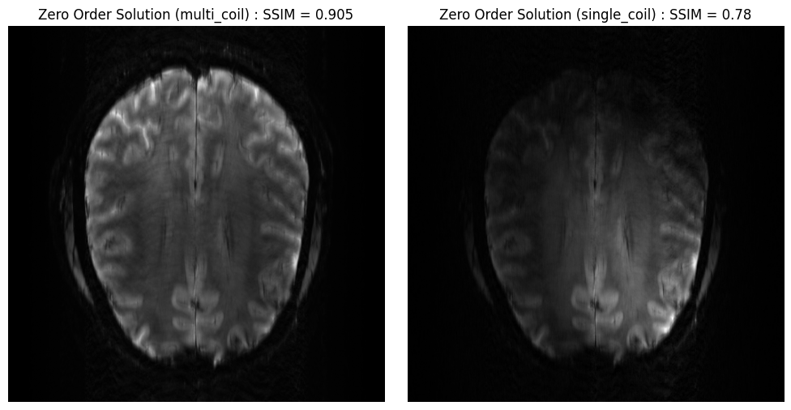

```python
fig, axs = plt.subplots(1, 2, figsize=(10, 5))

fourier_op_multi_coil = FFT(mask=mask, shape=image.shape,
                 n_coils=cartesian_ref_image.shape[0])
kspace_obs_multi_coil = fourier_op_multi_coil.op(cartesian_ref_image)
zero_soln_multi_coil = np.linalg.norm(fourier_op.adj_op(kspace_obs), axis=0)
base_ssim_multi_coil = ssim(zero_soln_multi_coil, image)
'''
plt.imshow(np.abs(zero_soln_multi_coil), cmap='gray')
plt.title('Zero Order Solution (multi_coil) : SSIM = ' + str(np.around(base_ssim, 3)))
plt.show()
'''
axs[0].imshow(np.abs(zero_soln_multi_coil), cmap='gray')
axs[0].set_title('Zero Order Solution (multi_coil) : SSIM = ' + str(np.around(base_ssim_multi_coil, 3)))
axs[0].axis('off')

fourier_op_single_coil = FFT(mask=mask, shape=image.shape,
                 n_coils=1)
kspace_obs_single_coil = fourier_op_single_coil.op(cartesian_ref_image)
zero_soln_single_coil = fourier_op_single_coil.adj_op(kspace_obs[0])
base_ssim_single_coil = ssim(zero_soln_single_coil, image)
'''
plt.imshow(np.abs(zero_soln_single_coil), cmap='gray')
plt.title('Zero Order Solution (single_coil) : SSIM = ' + str(np.around(base_ssim, 3)))
plt.show()
'''
axs[1].imshow(np.abs(zero_soln_single_coil), cmap='gray')
axs[1].set_title('Zero Order Solution (single_coil) : SSIM = ' + str(np.around(base_ssim_single_coil, 3)))
axs[1].axis('off')

plt.tight_layout()
plt.show()
```

$\leadsto$ There is a noticeable improvement in the reconstructed image quality when using multi-coil data compared to single-coil data :

- When using multi-coil data, we can take advantage of the different sensitivities of each MRI coil to generate a clearer reconstructed image ;
- While, when using single-coil data, this information is not utilized.

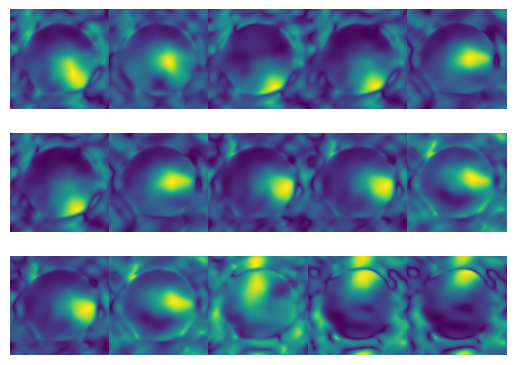

```python
# Obtain SMaps
kspace_loc = convert_mask_to_locations(mask)
'''
convert_mask_to_locations(mask) : 将 mask 转换为 k-space 采样坐标。
kspace_loc : 存储 被采样的 k-space 位置，用于 计算灵敏度图（SMaps）。
'''
Smaps, SOS = get_Smaps(
    k_space=kspace_obs,
    img_shape=fourier_op.shape,
    samples=kspace_loc,
    thresh=(0.01, 0.01),    # The cutoff threshold in each kspace direction
                            # between 0 and kspace_max (0.5)
    min_samples=kspace_loc.min(axis=0),
    max_samples=kspace_loc.max(axis=0),
    mode='gridding',
    method='linear',
    n_cpu=-1,
)
'''
get_Smaps() : 计算 MRI 灵敏度图（SMaps），即 每个线圈的空间响应，用于 并行 MRI（pMRI）重建。
Smaps： 每个 MRI 线圈的 灵敏度图（Sensitivity Maps） Smaps.shape = (n_coils, 512, 512)（每个线圈对应 512×512 图像）。
SOS（Sum-of-Squares 重建）： 多通道 MRI 数据的合成图像。
'''
h=3;w=5;
f, axs = plt.subplots(h,w)
for i in range(h):
    for j in range(w):
        axs[i, j].imshow(np.abs(Smaps[3 * i + j]))
        axs[i, j].axis('off')
plt.subplots_adjust(wspace=0,hspace=0)
'''
可视化 15 个 MRI 线圈的灵敏度图（SMaps）
h = 3, w = 5 : 3 行 5 列 共 15 个 SMaps。
Smaps[3 * i + j] : 选取 第 3*i + j 个线圈的 SMaps 进行可视化。
'''
plt.show()
```

```python
import os
print(os.environ.get('CUDA_HOME'))
```

```
/usr/local/cuda-12.6
```

```python
import pysap

from mri.operators import NonCartesianFFT, WaveletUD2, WaveletN
from mri.operators.utils import convert_locations_to_mask, \
    gridded_inverse_fourier_transform_nd
from mri.reconstructors import SingleChannelReconstructor
from pysap.data import get_sample_data

# Third party import
from modopt.math.metrics import ssim
from modopt.opt.linear import Identity
from modopt.opt.proximity import SparseThreshold
import numpy as np
import matplotlib.pyplot as plt
```

## FISTA optimization

We now want to refine the zero order solution using a FISTA optimization. The cost function is set to Proximity Cost + Gradient Cost

```python
# Setup the operators
linear_op = WaveletN(
    wavelet_name='sym8',
    nb_scale=4,
)
regularizer_op = SparseThreshold(Identity(), 1.5e-8, thresh_type="soft")
```

```python
# Setup Reconstructor
reconstructor = SelfCalibrationReconstructor(
    fourier_op=fourier_op,
    linear_op=linear_op,
    regularizer_op=regularizer_op,
    gradient_formulation='synthesis',
    kspace_portion=0.01,
    verbose=1,
)
```

```
WARNING: Making input data immutable.
WARNING: Making input data immutable.
```

```
Lipschitz constant is 1.097248267178452
 - mu:  1.5e-08
 - lipschitz constant:  1.097248267178452
 - data:  (512, 512)
 - wavelet:  <mri.operators.linear.wavelet.WaveletN object at 0x7fa510498310> - 4
 - max iterations:  200
 - image variable shape:  (512, 512)
 - alpha variable shape:  (291721,)
----------------------------------------
Starting optimization...
```

```
 - final iteration number:  200
 - final log10 cost value:  6.0
 - converged:  False
Done.
Execution time:  119.48237159199198  seconds
----------------------------------------
```

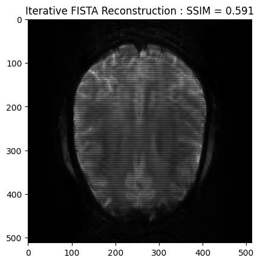

```python
image_rec, costs, metrics = reconstructor.reconstruct(
    kspace_data=kspace_obs,
    optimization_alg='fista',
    num_iterations=200,
)
recon_ssim = ssim(image_rec, image)
plt.imshow(np.abs(image_rec), cmap='gray')
plt.title('Iterative FISTA Reconstruction : SSIM = ' + str(np.around(recon_ssim, 3)))
plt.show()
```

## POGM reconstruction

```
WARNING: Making input data immutable.
```

```
Lipschitz constant is 1.097188038847508
 - mu:  1.5e-08
 - lipschitz constant:  1.097188038847508
 - data:  (512, 512)
 - wavelet:  <mri.operators.linear.wavelet.WaveletN object at 0x7fa510498310> - 4
 - max iterations:  200
 - image variable shape:  (1, 512, 512)
----------------------------------------
Starting optimization...
```

```
 - final iteration number:  200
 - final log10 cost value:  6.0
 - converged:  False
Done.
Execution time:  127.13897731900215  seconds
----------------------------------------
```

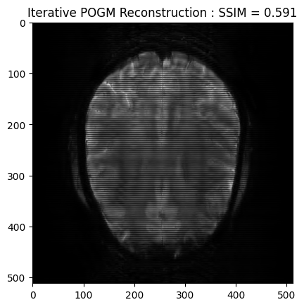

```python
image_rec2, costs, metrics = reconstructor.reconstruct(
    kspace_data=kspace_obs,
    optimization_alg='pogm',
    num_iterations=200,
)
recon2_ssim = ssim(image_rec2, image)
plt.imshow(np.abs(image_rec2), cmap='gray')
plt.title('Iterative POGM Reconstruction : SSIM = ' + str(np.around(recon2_ssim, 3)))
plt.show()
```

**Q2**

- Do the same for the CS-based (synthesis formulation) solutions (FISTA or POGM).

```python
print(fourier_op.op(cartesian_ref_image)[0].shape)
```

```
(512, 512)
```

```python
def reconstruction (coil):
    if coil == "multi_coil" :
        fourier_op = FFT(mask=mask, shape=image.shape,
                 n_coils=cartesian_ref_image.shape[0])
        kspace_obs = fourier_op.op(cartesian_ref_image)
    elif coil == "single_coil" :
        fourier_op = FFT(mask=mask, shape=image.shape,
                 n_coils=int(1))
        kspace_obs = fourier_op.op(cartesian_ref_image)[0].reshape(1, 512, 512)

    # Setup the operators
    linear_op = WaveletN(
        wavelet_name='sym8',
        nb_scale=4,
    )
    regularizer_op = SparseThreshold(Identity(), 1.5e-8, thresh_type="soft")

    # Setup Reconstructor
    reconstructor = SelfCalibrationReconstructor(
        fourier_op=fourier_op,
        linear_op=linear_op,
        regularizer_op=regularizer_op,
        gradient_formulation='synthesis',
        kspace_portion=0.01,
        verbose=1,
    )

    image_rec, costs, metrics = reconstructor.reconstruct(
        kspace_data=kspace_obs,
        optimization_alg='pogm',
        num_iterations=200,
    )
    recon_ssim = ssim(image_rec, image)

    return image_rec, recon_ssim
```

```
WARNING: Making input data immutable.
```

```
Lipschitz constant is 1.0971993561659803
 - mu:  1.5e-08
 - lipschitz constant:  1.0971993561659803
 - data:  (512, 512)
 - wavelet:  <mri.operators.linear.wavelet.WaveletN object at 0x7fa524173390> - 4
 - max iterations:  200
 - image variable shape:  (1, 512, 512)
----------------------------------------
```

```
WARNING: Making input data immutable.
```

```
Starting optimization...
```

```
 - final iteration number:  200
 - final log10 cost value:  6.0
 - converged:  False
Done.
Execution time:  126.77331336899078  seconds
----------------------------------------
```

```
WARNING: Making input data immutable.
WARNING: Making input data immutable.
```

```
Lipschitz constant is 1.099999988109965
 - mu:  1.5e-08
 - lipschitz constant:  1.099999988109965
 - data:  (512, 512)
 - wavelet:  <mri.operators.linear.wavelet.WaveletN object at 0x7fa526496250> - 4
 - max iterations:  200
 - image variable shape:  (1, 512, 512)
----------------------------------------
Starting optimization...
```

```
 - final iteration number:  200
 - final log10 cost value:  6.0
 - converged:  False
Done.
Execution time:  21.0308540550177  seconds
----------------------------------------
```

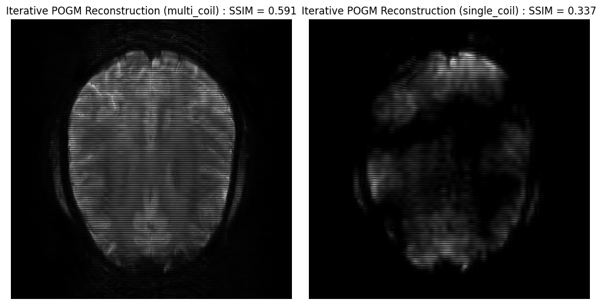

```python
fig, axs = plt.subplots(1, 2, figsize=(10, 5))

'''
fourier_op_multi_coil = FFT(mask=mask, shape=image.shape,
                 n_coils=cartesian_ref_image.shape[0])
kspace_obs_multi_coil = fourier_op_multi_coil.op(cartesian_ref_image)
zero_soln_multi_coil = np.linalg.norm(fourier_op.adj_op(kspace_obs), axis=0)
base_ssim_multi_coil = ssim(zero_soln_multi_coil, image)

plt.imshow(np.abs(zero_soln_multi_coil), cmap='gray')
plt.title('Zero Order Solution (multi_coil) : SSIM = ' + str(np.around(base_ssim, 3)))
plt.show()
'''
POGM_soln_multi_coil, POGM_ssim_multi_coil = reconstruction("multi_coil")
axs[0].imshow(np.abs(POGM_soln_multi_coil), cmap='gray')
axs[0].set_title('Iterative POGM Reconstruction (multi_coil) : SSIM = ' + str(np.around(POGM_ssim_multi_coil, 3)))
axs[0].axis('off')

'''
fourier_op_single_coil = FFT(mask=mask, shape=image.shape,
                 n_coils=1)
kspace_obs_single_coil = fourier_op_single_coil.op(cartesian_ref_image)
zero_soln_single_coil = fourier_op_single_coil.adj_op(kspace_obs[0])
base_ssim_single_coil = ssim(zero_soln_single_coil, image)

plt.imshow(np.abs(zero_soln_single_coil), cmap='gray')
plt.title('Zero Order Solution (single_coil) : SSIM = ' + str(np.around(base_ssim, 3)))
plt.show()
'''

POGM_soln_single_coil, POGM_ssim_single_coil = reconstruction("single_coil")

axs[1].imshow(np.abs(POGM_soln_single_coil), cmap='gray')
axs[1].set_title('Iterative POGM Reconstruction (single_coil) : SSIM = ' + str(np.around(POGM_ssim_single_coil, 3)))
axs[1].axis('off')

plt.tight_layout()
plt.show()
```

$\leadsto$ There is a noticeable improvement in the reconstructed image quality when using multi-coil data compared to single-coil data during the Iterative **POGM** Reconstruction :

- When using multi-coil data, we can take advantage of the different sensitivities of each MRI coil to generate a clearer reconstructed image ;
- While, when using single-coil data, this information is not utilized.

## Analysis formulation: Condat-Vu reconstruction

```python
#linear_op = WaveletN(wavelet_name="sym8", nb_scales=4)
linear_op = WaveletUD2(
    wavelet_id=24,
    nb_scale=4,
)
regularizer_op = SparseThreshold(Identity(), 4e-7, thresh_type="soft")
```

```python
# Setup Reconstructor
reconstructor = SelfCalibrationReconstructor(
    fourier_op=fourier_op,
    linear_op=linear_op,
    regularizer_op=regularizer_op,
    gradient_formulation='analysis',
    verbose=1,
)
```

```
WARNING: Making input data immutable.
```

```
Lipschitz constant is 1.0833965993430223
```

```
WARNING: <class 'mri.operators.linear.wavelet.WaveletUD2'> does not inherit an operator parent.
```

```
 - mu:  4e-07
 - lipschitz constant:  1.0833965993430223
 - tau:  0.9448185977588914
 - sigma:  0.5
 - rho:  1.0
 - std:  None
 - 1/tau - sigma||L||^2 >= beta/2:  True
 - data:  (512, 512)
 - wavelet:  <mri.operators.linear.wavelet.WaveletUD2 object at 0x7fa5107ba0d0> - 4
 - max iterations:  200
 - number of reweights:  0
 - primal variable shape:  (512, 512)
 - dual variable shape:  (2621440,)
----------------------------------------
Starting optimization...
```

```
 - final iteration number:  200
 - final cost value:  1000000.0
 - converged:  False
Done.
Execution time:  339.19452833998366  seconds
----------------------------------------
```

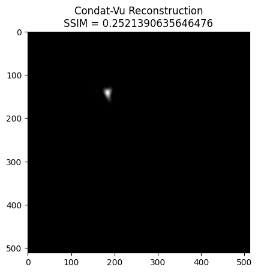

```python
x_final, costs, metrics = reconstructor.reconstruct(
    kspace_data=kspace_obs,
    optimization_alg='condatvu',
    num_iterations=200,
)
image_rec = pysap.Image(data=np.abs(x_final))
plt.imshow(np.abs(image_rec), cmap='gray')
recon_ssim = ssim(image_rec, image)
plt.title('Condat-Vu Reconstruction\nSSIM = {}'.format(recon_ssim))
plt.show()
```

**Q3** Analysis vs Synthesis CS-pMRI reconstruction:

Using the same sparsifying transform (i.e. `linear_op` set to `Dauchechies` `8`),

compare the results between the analysis (Condat-Vu algorithm) and synthesis (FISTA) self-calibrated formulations in the multicoil acquisition setting.

```python
def reconstruction_v1 (optimization_alg_) :

    fourier_op = FFT(mask=mask, shape=image.shape,
                 n_coils=cartesian_ref_image.shape[0])
    kspace_obs = fourier_op.op(cartesian_ref_image)

    # Setup the operators
    linear_op = WaveletN(
        wavelet_name='db8',
        nb_scale=4,
    )
    regularizer_op = SparseThreshold(Identity(), 1.5e-8, thresh_type="soft")

    if optimization_alg_ == "fista":

        # Setup Reconstructor
        reconstructor = SelfCalibrationReconstructor(
            fourier_op=fourier_op,
            linear_op=linear_op,
            regularizer_op=regularizer_op,
            gradient_formulation='synthesis',
            kspace_portion=0.01,
            verbose=1,
        )

        image_rec, costs, metrics = reconstructor.reconstruct(
            kspace_data=kspace_obs,
            optimization_alg='fista',
            num_iterations=200,
        )
        recon_ssim = ssim(image_rec, image)

    elif optimization_alg_ == "condatvu":
        # Setup Reconstructor
        reconstructor = SelfCalibrationReconstructor(
            fourier_op=fourier_op,
            linear_op=linear_op,
            regularizer_op=regularizer_op,
            gradient_formulation='analysis',
            verbose=1,
        )

        x_final, costs, metrics = reconstructor.reconstruct(
            kspace_data=kspace_obs,
            optimization_alg='condatvu',
            num_iterations=200,
        )
        image_rec = pysap.Image(data=np.abs(x_final))
        recon_ssim = ssim(image_rec, image)

    return image_rec, recon_ssim
```

```
Lipschitz constant is 1.0972648969380223
 - mu:  1.5e-08
 - lipschitz constant:  1.0972648969380223
 - data:  (512, 512)
 - wavelet:  <mri.operators.linear.wavelet.WaveletN object at 0x7fa524134590> - 4
 - max iterations:  200
 - image variable shape:  (512, 512)
 - alpha variable shape:  (291721,)
----------------------------------------
Starting optimization...
```

```
 - final iteration number:  200
 - final log10 cost value:  6.0
 - converged:  False
Done.
Execution time:  116.62128731000121  seconds
----------------------------------------
```

```
WARNING: Making input data immutable.
WARNING: Making input data immutable.
WARNING: <class 'mri.operators.linear.wavelet.WaveletN'> does not inherit an operator parent.
```

```
Lipschitz constant is 1.0833981375885406
 - mu:  1.5e-08
 - lipschitz constant:  1.0833981375885406
 - tau:  0.9599701299126275
 - sigma:  0.5
 - rho:  1.0
 - std:  None
 - 1/tau - sigma||L||^2 >= beta/2:  True
 - data:  (512, 512)
 - wavelet:  <mri.operators.linear.wavelet.WaveletN object at 0x7fa52648ae90> - 4
 - max iterations:  200
 - number of reweights:  0
 - primal variable shape:  (512, 512)
 - dual variable shape:  (291721,)
----------------------------------------
Starting optimization...
```

```
 - final iteration number:  200
 - final cost value:  1000000.0
 - converged:  False
Done.
Execution time:  120.3171403669985  seconds
----------------------------------------
```

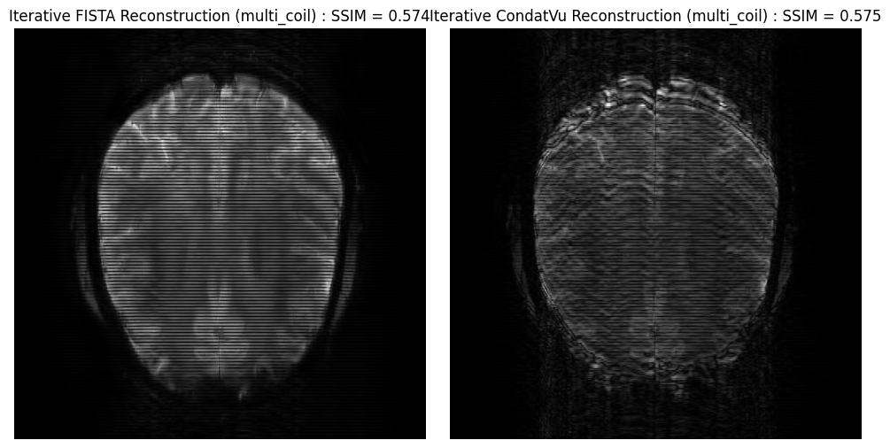

```python
fig, axs = plt.subplots(1, 2, figsize=(10, 5))


FISTA_soln_multi_coil, FISTA_ssim_multi_coil = reconstruction_v1 ("fista")
axs[0].imshow(np.abs(FISTA_soln_multi_coil), cmap='gray')
axs[0].set_title('Iterative FISTA Reconstruction (multi_coil) : SSIM = ' + str(np.around(FISTA_ssim_multi_coil, 3)))
axs[0].axis('off')

CondatVu_soln_multi_coil, CondatVu_ssim_multi_coil = reconstruction_v1 ("condatvu")

axs[1].imshow(np.abs(CondatVu_soln_multi_coil), cmap='gray')
axs[1].set_title('Iterative CondatVu Reconstruction (multi_coil) : SSIM = ' + str(np.around(CondatVu_ssim_multi_coil, 3)))
axs[1].axis('off')

plt.tight_layout()
plt.show()
```

Under the same operators conditions as

> `linear_op = WaveletN(wavelet_name='db8', nb_scale=4)`

> `regularizer_op = SparseThreshold(Identity(), 1.5e-8, thresh_type="soft")`

and

## Configuration

```python
!nvcc --version
```

```
nvcc: NVIDIA (R) Cuda compiler driver
Copyright (c) 2005-2024 NVIDIA Corporation
Built on Tue_Oct_29_23:50:19_PDT_2024
Cuda compilation tools, release 12.6, V12.6.85
Build cuda_12.6.r12.6/compiler.35059454_0
```

```python
import tensorflow as tf
print(tf.__version__)  # 查看 TensorFlow 版本
print(tf.config.list_physical_devices('GPU'))  # 查看 GPU 设备
```

```
2.18.0
[PhysicalDevice(name='/physical_device:GPU:0', device_type='GPU')]
```

```python
import torch
print(torch.__version__)  # 查看 PyTorch 版本
print(torch.cuda.is_available())  # 查看是否有 GPU 可用
print(torch.cuda.get_device_name(0))  # 查看使用的 GPU 名称
print(torch.version.cuda)  # 查看 CUDA 版本
```

```
2.7.0.dev20250224+cu126
True
NVIDIA T1200 Laptop GPU
12.6
```